# Assignment 3

Carl Xi

11/4/2019

```r
library(data.table)
library(igraph)
library(stringr)
library(splitstackshape)
library(plotly)
library(network)
library(lubridate)
library(zoo)
library(plm)
library(pglm)
library(dplyr)
library(ggplot2)
library(panelAR)

rm(list = ls(all = TRUE))

setwd("C:/Users/carlj/OneDrive/Documents/School-MSBA/Classes/Fall/Social Network Analytics/Assignment 3")

#Let's first import all the data packages
DistrictRaw <- fread("district_information.csv", header = TRUE)
RainRaw <- fread("rain_information.csv", header = TRUE)
BorderRaw <- fread("border_information.csv", header = TRUE)
NewPartyRaw <- fread("new_parties_in_each_district_by_candidate.csv", header = TRUE)

#We only care about Rain data between 1951 and 1999, so let's remove the rest
RainRaw<-RainRaw[RainRaw$year>"1950"& RainRaw$year<"2000",]

#Let's remove all NA variables
RainRaw$rain[RainRaw$rain == 0] <- NA
RainRaw <- na.omit(RainRaw)

#Let's remove all NA/Null Variables from New Party as well
NewPartyRaw <- NewPartyRaw[NewPartyRaw$party_name != ""]
NewPartyRaw <- na.omit(NewPartyRaw)

#The year 1985 has suspiciously little data. A brief Google search reveals that the previous Prime Minister was assassinated in 1984, and elections didn't occur until 1985. Thus, we will remove 1985 data from district information
DistrictRaw <- DistrictRaw[DistrictRaw$year != 1985]

#Looking at the Raw Border data, we can see that it is directed. We can make our lives easier for the following questions by simply putting district first instead of focal_district. This will give us information of both columns.

#We create a reversed border dataframe
BorderRaw2 <- cbind.data.frame(focal_district = BorderRaw$district, district = BorderRaw$focal_district)
#We bind the normal and reversed together
BorderRaw <- rbind.data.frame(BorderRaw, BorderRaw2)

#We remove any duplicates
BorderRaw <- unique(BorderRaw)
```

Question 1:

First, we will set up the relationship between RainRaw and political party foundings, and then modify the RainRaw measure to generate a statistically independent measure for droughts. This modification will allow us to isolate the effect of economic strain on political parties from other underlying features of a region that might influence its political structure.

1. Create a figure, for example, a scatter plot, showing the visual relationship between the level of RainRaw in a district in the period leading up to the current election, and the number of political parties that are founded in a region.

You can use the raw RainRaw measure or the Standardized Precipitation Index. You can consider the level of RainRaw for each election period in terms of (1) the sum of the raw RainRaw during the interval starting from the year following the previous election up until the year of the current election or (2) the yearly average of the Standardized Precipitation Index during the interval starting from the year following the previous election up until the year of the current election.

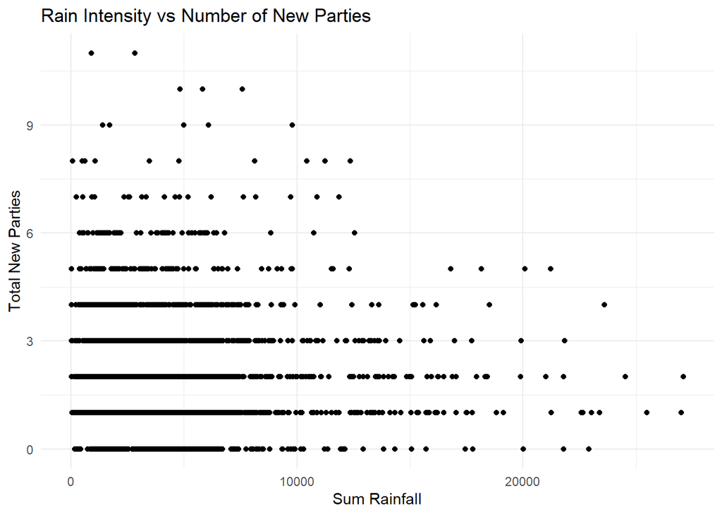

```r
#Let's create a revised version of the rain datatable
RainAlt <- data.frame()

#We can get all the election years by looking at all the years of the first district
ElectionYear <- DistrictRaw$year[1:13]

#The outer for loop isolates every district's entire historical data
for (i in unique(RainRaw$district)) {
  DistrictSubset <- RainRaw[RainRaw$district == i]
  x <- 1

  #The inner for loop loops through every year of the district that's isolated
  for (j in ElectionYear) {
    #Creates a copy of rain data
    RainAlt2 <- RainAlt

    #We record the district, year, and calculate the average SPI and total amount of rain for that district for each election period
    RainAlt <- cbind.data.frame(district = i, year = j, DistrictSubset[x:(which(DistrictSubset$year == j)),] %>% summarise(AvgSPI = mean(spi), TotalRain = sum(rain)))

    #We then bind the data together
    RainAlt <- rbind.data.frame(RainAlt2, RainAlt)

    #We then loop this for all districts
    x <- 1 + which(DistrictSubset$year == j)
  }
}


#Time to combine
#Let's combine the Rain and District datasets
RainDistrict <- inner_join(DistrictRaw,RainAlt,by=c("district","year"))
#With the district and rain data combined, we can now create our first plot of sum rainfall vs number of parties

ggplot(RainDistrict, aes(y = new_parties, x = TotalRain)) + geom_point() + labs(title ="Rain Intensity vs Number of New Parties", x = "Sum Rainfall", y = "Total New Parties") + theme_minimal()
```

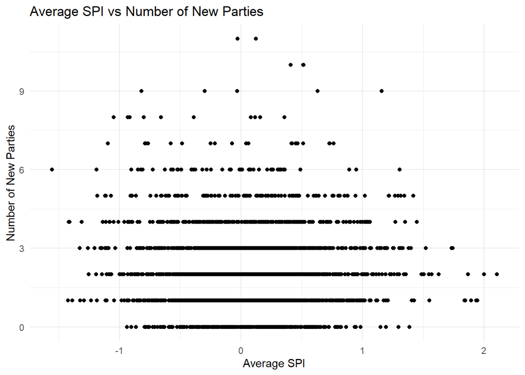

```r
#Let's also take a look at average SPIl vs number of parties

ggplot(RainDistrict, aes(y = new_parties, x = AvgSPI)) + geom_point() + labs(title ="Average SPI vs Number of New Parties", x = "Average SPI", y = "Number of New Parties") + theme_minimal()
```

2. Using the election-period level rainfall measures created above, show that the raw level of rainfall, as well as the Standardized Precipitation Index, are not independent from one election period to the next within a district, as well as from neighboring districts from one election period to the next.

It is possible to show this relationship by regressing a district’s current level of the rainfall variable on (1) its lagged value and (2) the lagged value of its neighbors’ rainfall variable. For computing the neighbors’ value, you can use an average of each of the surrounding districts’ values. Include a control in the regression for the number of years in the election period, and use a fixed effects specification to control for the time-invariant features of a district as well as a control for each election period. This can be accomplished using the plm package, using a model specified in the form of plm(outcome variable ∼ predictor variables, data, effect = “twoways”, model = “within”, index = “district”), where “twoways”, “within” provide both sets of fixed effects. Create a table, and 2 new columns of the lagged value of rainfull and SPI:

```r
#Let's create a copy of our cleaned rain data for regression purposes
RainRegress <- RainAlt

#Let's calculate the lag for SPI and Rain then append it to our regression datatable
RainRegress$SPILag <- append(0,RainRegress$AvgSPI[-length(RainRegress$district)])
RainRegress$RainLag <- append(0,RainRegress$TotalRain[-length(RainRegress$district)])

#Let's create a new dataframe for storing the lag of the neighbors
NeighborLag <- data.frame()

#We loop through every unique district
for (i in unique(RainRegress$district)) {

  # We find the list of neighbors for each district
  NeighborList <- as.vector(BorderRaw[which(BorderRaw$focal_district == i),2])

  #We subset the rain data so that only neighbor data remains
  #We then group by year, and calculate the average rain and SPI lag of neighbors
  NeighborLagN <- RainRegress[RainRegress$district %in% NeighborList$district,] %>% group_by(year) %>% summarise(SPILagN = mean(SPILag), RainLagN = mean(RainLag), district = i)

  #Finally, we bind the data into the dataframe we created above
  NeighborLag <- rbind.data.frame(NeighborLag,NeighborLagN)
}

#We can now combine the neighbor lag data into the rain data for regression using inner join
RainRegress <- inner_join(RainRegress,NeighborLag,by = c("district","year"))
#We create an empty list to store the index of the first election year of every district
Index1 <- c()

#We loop through every unique district
for (i in unique(RainRegress$district)) {
  #We encode the index of the first election year
  Index2 <- first(which(RainRegress$district == i))
  #We then append it to our list of indexes
  Index1 <- append(Index1,Index2)
}

#Since we are dealing with lag, we need to remove the first year of every district.
RainRegress <- RainRegress[-Index1,]

#We will also calculate the years between each election year, which we are forced to hardcode year by year. Luckly there isn't too many years. We first encode all intervals as 0 to cover 1951 (The first year), then individually encode each subsequent year
RainRegress$interval <- 0
RainRegress[RainRegress$year == 1957,][,'interval'] <- 6
RainRegress[RainRegress$year == 1962,][,'interval'] <- 5
RainRegress[RainRegress$year == 1967,][,'interval'] <- 5
RainRegress[RainRegress$year == 1971,][,'interval'] <- 4
RainRegress[RainRegress$year == 1977,][,'interval'] <- 6
RainRegress[RainRegress$year == 1980,][,'interval'] <- 3
RainRegress[RainRegress$year == 1984,][,'interval'] <- 4
RainRegress[RainRegress$year == 1989,][,'interval'] <- 5
RainRegress[RainRegress$year == 1991,][,'interval'] <- 2
RainRegress[RainRegress$year == 1996,][,'interval'] <- 5
RainRegress[RainRegress$year == 1998,][,'interval'] <- 2
RainRegress[RainRegress$year == 1999,][,'interval'] <- 1

#Data Preparation for regression is finally complete
```

```r
#With all the data preparation complete, we can now finally perform regression

#We first perform regression on total rain using the rain lag information and the rain lag of the neighbors. We will also be using the duration between election years as a factor variable for control
RainRegression1 <- plm(TotalRain ~ RainLag + RainLagN + factor(interval), RainRegress, effect = "twoways", model = "within", index = "district")

#We look at summary statistics
summary(RainRegression1)
```

```
## Twoways effects Within Model
##
## Call:
## plm(formula = TotalRain ~ RainLag + RainLagN + factor(interval),
##     data = RainRegress, effect = "twoways", model = "within",
##     index = "district")
##
## Balanced Panel: n = 292, T = 12, N = 3504
##
## Residuals:
##      Min.   1st Qu.    Median   3rd Qu.      Max.
## -9150.389  -528.643   -12.729   528.233  8359.784
##
## Coefficients:
##           Estimate Std. Error t-value  Pr(>|t|)
## RainLag   0.162814   0.029847  5.4550 5.269e-08 ***
## RainLagN -0.204796   0.030577 -6.6978 2.490e-11 ***
## ---
## Signif. codes:  0 '***' 0.001 '**' 0.01 '*' 0.05 '.' 0.1 ' ' 1
##
## Total Sum of Squares:    7725800000
## Residual Sum of Squares: 7618900000
## R-Squared:      0.013838
## Adj. R-Squared: -0.079877
## F-statistic: 22.4437 on 2 and 3199 DF, p-value: 2.092e-10
```

```r
#Similarily, we perform regression on average SPI, also with its lag and neighbor lag as predictor variables. Again, we use interval as a factor variable for control.
SPIRegression1 <- plm(AvgSPI ~ SPILag + SPILagN + factor(interval), RainRegress, effect = "twoways", model = "within", index = "district")

#We look at summary statistics
summary(SPIRegression1)
```

```
## Twoways effects Within Model
##
## Call:
## plm(formula = AvgSPI ~ SPILag + SPILagN + factor(interval), data = RainRegress,
##     effect = "twoways", model = "within", index = "district")
##
## Balanced Panel: n = 292, T = 12, N = 3504
##
## Residuals:
##      Min.   1st Qu.    Median   3rd Qu.      Max.
## -1.414525 -0.284766 -0.026721  0.262577  1.741512
##
## Coefficients:
##          Estimate Std. Error t-value  Pr(>|t|)
## SPILag   0.315976   0.039627  7.9737 2.124e-15 ***
## SPILagN -0.173673   0.043858 -3.9599 7.662e-05 ***
## ---
## Signif. codes:  0 '***' 0.001 '**' 0.01 '*' 0.05 '.' 0.1 ' ' 1
##
## Total Sum of Squares:    731.51
## Residual Sum of Squares: 704.08
## R-Squared:      0.037489
## Adj. R-Squared: -0.053979
## F-statistic: 62.2985 on 2 and 3199 DF, p-value: < 2.22e-16
```

```r
#For both Total Rain and Average SPI, we can see that the district's own lag is positively correlated with the dependent variable, where as the lag of the district's neighbors is negatively correlated with the dependent variable. This means that the amount of rain and SPI value for a region is positively correlated with the amount of rain and SPI value for the region for the previous period, while negatively correlated with the amound of rain and SPi value for the region's neighboring regions' previous periods.
```

3. Meteorological scientists consider moderate droughts to occur if the Standardized Precipitation Index falls below -1, and moderate floods to occur if it rises above 1.

Create a measure that sums the number of years a district experiences either moderate droughts or floods during the interval starting from the year following the previous election up until the year of the current election. Perform the same test as in (B), using this new transformed measure. This measure will form the basis for the predictors used in the remainder of the regressions in Questions 2-5.

Since this is a count outcome that is reported as a discrete number of years, use a regression adopted for data of this form—this can be accomplished with the pglm package, using a model specified in the form of pglm(outcome variable ∼ predictor variables, data, effect = “twoways”, model = “within”, index = “district”, family = “poisson”). What differences do you see between the estimates?

```r
#We basically repeat quesiton 1-a but for extreme weather calculation for each inter-election period
#Let's create a revised version of the rain datatable
ExRain <- data.frame()

#The outer for loop isolates every district's entire historical data
for (i in unique(RainRaw$district)) {
  DistrictSubset <- RainRaw[RainRaw$district == i]
  x <- 1

  #The inner for loop loops through every year of the district that's isolated
  for (j in ElectionYear) {
    #Creates a copy of rain data
    ExRain2 <- ExRain
    #We record the district, year, and sum up number of extreme weather years for that district for each election period
    ExRain <- cbind.data.frame(district = i, year = j, DistrictSubset[x:(which(DistrictSubset$year == j)),] %>% summarise(ExWeather = sum(spi < -1 | spi > 1)))

    #We then bind the data together
    ExRain <- rbind.data.frame(ExRain2, ExRain)

    #We then loop this for all districts
    x <- 1 + which(DistrictSubset$year == j)
  }
}

#Let's create a copy of our cleaned rain data for regression purposes
ExRainRegress <- ExRain

#Let's calculate the lag for extreme weather and Rain then append it to our regression datatable
ExRainRegress$ExLag <- append(0,ExRainRegress$ExWeather[-length(ExRainRegress$ExWeather)])
#Again, we don't need 1951 if we are working with lag
ExRainRegress <- ExRainRegress %>% filter(year != 1951)

#Let's create a new dataframe for storing the lag of the neighbors
ExNeighborLag <- data.frame()
#We loop through every unique district
for (i in unique(ExRainRegress$district)) {
  # We find the list of neighbors for each district
  NeighborList <- as.vector(BorderRaw[which(BorderRaw$focal_district == i),2])

  #We subset the rain data so that only neighbor data remains
  #We then group by year, and calculate the average Extreme weather lag of neighbors
  ExNeighborLagN <- ExRainRegress[ExRainRegress$district %in% NeighborList$district,] %>% group_by(year) %>% summarise(ExNeighborLag = mean(ExLag), district = i)
  #Finally, we bind the data into the dataframe we created above
  ExNeighborLag <- rbind.data.frame(ExNeighborLag,ExNeighborLagN)
}

#We can now combine the neighbor lag data into the extreme weather data for regression using inner join
ExRainRegress <- inner_join(ExRainRegress,ExNeighborLag,by = c("district","year"))
#Just like in 1-b, we need to hardcode the intervals between election years
#We will again calculate the years between each election year, which we are forced to hardcode year by year. Luckly there isn't too many years. We first encode all intervals as 0 to cover 1951 (The first year), then individually encode each subsequent year
ExRainRegress$interval <- 0
ExRainRegress[ExRainRegress$year == 1957,][,'interval'] <- 6
ExRainRegress[ExRainRegress$year == 1962,][,'interval'] <- 5
ExRainRegress[ExRainRegress$year == 1967,][,'interval'] <- 5
ExRainRegress[ExRainRegress$year == 1971,][,'interval'] <- 4
ExRainRegress[ExRainRegress$year == 1977,][,'interval'] <- 6
ExRainRegress[ExRainRegress$year == 1980,][,'interval'] <- 3
ExRainRegress[ExRainRegress$year == 1984,][,'interval'] <- 4
ExRainRegress[ExRainRegress$year == 1989,][,'interval'] <- 5
ExRainRegress[ExRainRegress$year == 1991,][,'interval'] <- 2
ExRainRegress[ExRainRegress$year == 1996,][,'interval'] <- 5
ExRainRegress[ExRainRegress$year == 1998,][,'interval'] <- 2
ExRainRegress[ExRainRegress$year == 1999,][,'interval'] <- 1

#Data Preparation for regression is again complete for 1-c
```

```r
#Last step for 1-c, just like in 1-b, is to perform regression on Extreme weather based on its lag and the lag of the districts' neighbors

ExRegression1 <- pglm(ExWeather ~ ExLag + ExNeighborLag + interval, ExRainRegress, effect = "twoways", model = "within", index = "district", family = "poisson")
summary(ExRegression1)
```

```
## --------------------------------------------
## Maximum Likelihood estimation
## Newton-Raphson maximisation, 3 iterations
## Return code 1: gradient close to zero
## Log-Likelihood: -3394.709
## 3  free parameters
## Estimates:
##                Estimate Std. error t value Pr(> t)
## ExLag         -0.001362   0.032068  -0.042   0.966
## ExNeighborLag  0.020557   0.038627   0.532   0.595
## interval       0.329684   0.013694  24.076  <2e-16 ***
## ---
## Signif. codes:  0 '***' 0.001 '**' 0.01 '*' 0.05 '.' 0.1 ' ' 1
## --------------------------------------------
```

```r
#Looking at the regression coefficients, we we can see that both lag and neighbor lag for extreme weather are extremely weakly correlated with extreme weather for each region. With correlations of below an absolutely value of 0.02, we can say that extreme weather appearing in a region is not associated with whether or not the region experienced extreme weather in the previous period, and/or whether its neighbors just experienced extreme weather. This is quite counterintuitive in a sense.

#Comparing 1b and 1c, we can see that extreme weather is a lot more random than total rain and average SPI. Thus, we should proceed question 2-5 using extreme weather, as it in theory will be a better variable for modling the diffusion of political activity. Furthermore, we will also be using neighbor lag of extreme weather to diffusion effect.
```

2. Next, let’s analyze whether there are more new political parties when droughts or floods occur.

Run a regression predicting the number of new political parties that are formed as a function of the number of years a district experiences droughts or flooding in the interval starting from the year following the previous election up until the year of the current election.

The number of new political parties that enter a district is a discrete count outcome. However, it is likely that the rate of entry of political parties in any particular district in a particular period is also related, or “autocorrelated”, over time, to the rate of entry in the prior period’s of this district’s history. As a result, we will use a feasible generalized least squares estimator that can take into account district-specific autocorrelation. This can be accessed through the panelAR package using a model of the form panelAR(outcome variable ∼ predictor variables, data, panelVar, timeVar, autoCorr = “psar1”, panelCorrMethod = “phet”, rho.na.rm = TRUE).